# AdultCensus-NN

### Experiment with Reproducible Experiement Platform (REP) classification neural nets

- input previously preprocessed adult census dataset
- perform various experiements with theanets, pybrain, and neurolab classifiers
- evaluate results
- note: unable to evaluate the neurolab classifier producing eroneous results

```python
import numpy as np
import pandas as pd
import matplotlib as mpl
import matplotlib.pyplot as plt
import time
import random

# Using REP (Reproducible Experiement Platform) Package
# http://yandex.github.io/rep/index.html#
from rep.estimators import SklearnClassifier
from rep.estimators import XGBoostClassifier

# Neural Nets
from rep.estimators import TheanetsClassifier
from rep.estimators import PyBrainClassifier
from rep.estimators import NeurolabClassifier

# Ensembles
from sklearn.ensemble import RandomForestClassifier
from sklearn.ensemble import GradientBoostingClassifier
from sklearn.ensemble import AdaBoostClassifier
from sklearn.ensemble import ExtraTreesClassifier
from sklearn.ensemble import BaggingClassifier

# Tools
from sklearn import cross_validation
from sklearn.preprocessing import StandardScaler
from sklearn.grid_search import GridSearchCV
from sklearn.metrics import mean_squared_error
from sklearn.metrics import accuracy_score, precision_score, recall_score, f1_score
from sklearn.metrics import roc_curve, auc, confusion_matrix, classification_report
from sklearn.metrics import roc_auc_score

from rep.utils import train_test_split

from sklearn.cross_validation import cross_val_score, KFold
#from sklearn.cross_validation import train_test_split, cross_val_score, KFold

# use '/' for floating point division and '//' for integer division
from __future__ import division

# numpy print options - default
np.set_printoptions(edgeitems=3,infstr='inf',linewidth=75,nanstr='nan',precision=8,suppress=False,threshold=1000,formatter=None)

# my numpy print customizations
np.set_printoptions(linewidth=110,precision=3)

# pandas display all columns
pd.set_option('display.max_columns', None)
pd.set_option('max_colwidth', 500)

%matplotlib inline
```

```python
%pwd
```

```
u'/notebooks'
```

```python
cd /notebooks
```

```
/notebooks
```

## Load the dataset

The dataset was preprocessed in earlier primary notebook

```python
df = pd.read_csv('adult.csv', index_col=None)
```

```python
df.head(1)
```

|  | incomegt50k | age | workclass_without_pay | workclass_state_gov | workclass_self_emp_not_inc | workclass_self_emp_inc | workclass_private | workclass_never_worked | workclass_local_gov | workclass_federal_gov | workclass_? | fnlwgt | education_some_college | education_prof_school | education_preschool | education_masters | education_hs_grad | education_doctorate | education_bachelors | education_assoc_voc | education_assoc_acdm | education_9th | education_7th_8th | education_5th_6th | education_1st_4th | education_12th | education_11th | education_10th | education_num | … |
| --- | --- | --- | --- | --- | --- | --- | --- | --- | --- | --- | --- | --- | --- | --- | --- | --- | --- | --- | --- | --- | --- | --- | --- | --- | --- | --- | --- | --- | --- | --- |
| 0 | 0 | 50 | 0 | 0 | 1 | 0 | 0 | 0 | 0 | 0 | 0 | 83311 | 0 | 0 | 0 | 0 | 0 | 0 | 1 | 0 | 0 | 0 | 0 | 0 | 0 | 0 | 0 | 0 | 13 | … |

```python
targetName = 'incomegt50k'
```

```python
# Distribution of passed column
def Column_Dist(dfL, columnL):
    print dfL[columnL].value_counts() / len(dfL)
    print
    print dfL[columnL].value_counts()
    print
    print len(dfL)
    return

Column_Dist(df, targetName)
```

```
0    0.760713
1    0.239287
Name: incomegt50k, dtype: float64

0    37154
1    11687
Name: incomegt50k, dtype: int64

48841
```

### Reduce the dataset size for setup

```python
# Reduce data set size for incremental development
per = 1
recs_to_drop = int((1-per)*df.shape[0])
idxs = random.sample(range(df.shape[0]), recs_to_drop)
df.drop(idxs, inplace=True)
df.reset_index(drop=True, inplace=True)
df.shape
```

```
(48841, 109)
```

```python
Column_Dist(df, targetName)
```

```
0    0.760713
1    0.239287
Name: incomegt50k, dtype: float64

0    37154
1    11687
Name: incomegt50k, dtype: int64

48841
```

### Split the Target / Input Features and Create Training / Testing Datasets

Use a 40% test sample.

```python
def Split_And_Create_Datasets():
    global X_train, X_test, y_train, y_test, variables

    y = df[targetName]
    X = df.drop([targetName], axis = 1)

    variables = X.columns

    print('\nFull Target Data:    ' + str(y.shape))
    print('Full Feature Data:   ' + str(X.shape))

    X_train, X_test, y_train, y_test = cross_validation.train_test_split(X, y, test_size=.4, random_state=0)

    print('\nTraining Data:   ' + str(X_train.shape))
    print('Training Target: ' + str(y_train.shape))
    print('\nTest Data:       ' + str(X_test.shape))
    print('Test Target:     ' + str(y_test.shape))
    return

Split_And_Create_Datasets()
```

```
Full Target Data:    (48841,)
Full Feature Data:   (48841, 108)

Training Data:   (29304, 108)
Training Target: (29304,)

Test Data:       (19537, 108)
Test Target:     (19537,)
```

### Classifier Reporting Functions

All grid searches and classifier results will be captured in a data frame and exported to csv for analysis.

```python
def Class_Results_Init():
    global df_ClassR
    df_ClassR = pd.DataFrame(columns= ['Model','GridParms','GridBest','GridCVScore','Estimator','ConfMatrix','Roc','A','CVMean','CVspMean','P','R','F1','TrainDta','Sec','Date'])
    return
```

```python
def Class_Results(outfileL=''):
    global df_ClassR
    if outfileL:
        outfile = outfileL + '_' + time.strftime("%y%m%d.%H%M%S") + '.csv'
        df_ClassR.to_csv(outfile, header=True)
    return(df_ClassR.sort_values(['A'], ascending=False))
```

```python
def Class_Results_Add(ResultListL):
    global df_ClassR
    if df_ClassR.empty:
        idx = 0
    else:
        idx = df_ClassR.index.max() + 1
    df_ClassR.loc[idx] = ResultListL
    return
```

```python
def Roc_Plot_Setup(entriesL=25):
    # setup arrays to capture roc plot information
    global mdl, fpr, tpr, rocno
    mdl = np.empty( (entriesL,), dtype=[('mdl',object)] )
    fpr = np.empty( (entriesL,), dtype=[('fpr',object)] )
    tpr = np.empty( (entriesL,), dtype=[('tpr',object)] )
    rocno = 0
    return
```

```python
def Roc_Plot_Add(mdlL='missing'):
    # add current true positive and false positive arrays, model name is passed in
    global mdl, fpr, tpr, rocno
    mdl['mdl'][rocno]=mdlL
    fpr['fpr'][rocno]=fprL
    tpr['tpr'][rocno]=tprL
    rocno += 1
    return
```

```python
def Roc_Plot_Show():
    plt.figure(figsize=(12,10))

    for i in range(rocno):
        roc_auc = auc(fpr['fpr'][i], tpr['tpr'][i])
        plt.plot(fpr['fpr'][i], tpr['tpr'][i], label=mdl['mdl'][i] + ' (area = %0.3f)' % roc_auc)

    plt.plot([0, 1], [0, 1], 'k--')
    plt.xlim([-0.01, 1.0])
    plt.ylim([0.0, 1.01])
    plt.xlabel('False Positive Rate')
    plt.ylabel('True Positive Rate')
    plt.title('ROC Curve')
    plt.legend(loc="lower right")
    plt.show()
    return
```

### Model Fit and Predict Function

This function is utilized for all the sci-kit learn classifiers. It accepts a classifier as primary input parameter. If grid search parameters are passed, it will perform a grid search and then fit the model based on the best estimator.

Since the dataset is imbalanced and the minority class is the class of interest (people making > 50K, or true '1'), the grid search will score based on 'recall'.

A 7-fold cross validation will be calculated using both 'recall' and 'accuracy'(or the default classifier scoring).

```python
def Fit_Predict_Classifier(modelL, gridParmsL={}):
    global X_train, X_test, y_train, y_test
    global df_feat_importance
    global fprL, tprL

    scoring_parm = 'recall'   # since we have imbalanced dataset and we are interested in minority class
    best = {}
    score = 0

    start = time.time()                 # start time

    if gridParmsL:
        grid = GridSearchCV(modelL, gridParmsL, scoring=scoring_parm, cv=7, n_jobs=-1)
        # http://scikit-learn.org/stable/modules/model_evaluation.html#scoring-parameter
        grid.fit(X_train, y_train)
        best = grid.best_params_
        score = round(grid.best_score_,3)
        if log:
            #print "SCORES", grid.grid_scores_
            print 'Score based on: ' + scoring_parm
            print 'Best Score: ', grid.best_score_
            print 'Best Parameters: ', grid.best_params_
        # use the best estimator to fit and predict
        modelL = grid.best_estimator_

    # fit the model
    modelL.fit(X_train, y_train)

    # predict
    predicted = modelL.predict(X_test)

    prob = modelL.predict_proba(X_test)
    fprL, tprL, _ = roc_curve(y_test, modelL.predict_proba(X_test)[:,1])

    actual = y_test
    cm = confusion_matrix(actual, predicted)
    a = round(accuracy_score(actual, predicted),3)
    p = round(precision_score(actual, predicted),3)
    r = round(recall_score(actual, predicted),3)
    f1 = round(f1_score(actual, predicted),3)
    roc = round(roc_auc_score(actual, prob[:, 1]),3)

    # cross validation based on estimator
    cv = cross_val_score(modelL, X_train, y_train, scoring=None, cv=7, n_jobs=-1)
    cvm = round(cv.mean(),3)

    # cross validation based on the scoring_parm set above
    cvsp = cross_val_score(modelL, X_train, y_train, scoring=scoring_parm, cv=7, n_jobs=-1)
    cvspm = round(cvsp.mean(),3)

    try:
        df_feat_importance = modelL.get_feature_importances().sort_values(['effect'], ascending=False)
    except:
        df_feat_importance = []

    end = time.time()                   # end time
    elapsed = int(end - start)          # elapsed time

    if log:
        modelL_desc = str(modelL).split('(')[0]
        print '\n----- ' + modelL_desc + ' -------'
        print'\nModel:'
        print modelL
        print '\nCV Scoring Parm (' + scoring_parm + '):'
        print cvsp, ' Mean: ', cvspm
        print '\nCV Classifier Scoring Parm: '
        print cv, ' Mean: ', cvm
        print '\nOverall Accuracy:', a
        print
        print classification_report(actual, predicted)
        print confusion_matrix(actual, predicted, labels=None)
        print '\nROC AUC: ', roc

    est = str(modelL).replace('\n','')
    dte = str(time.strftime("%y%m%d.%H%M%S"))

    return([modelL_desc,gridParmsL,best,score,est,cm,roc,a,cvm,cvspm,p,r,f1,X_train.shape,elapsed,dte])
```

## Begin Classification

```python
# Initialize Classifiers Results DF
Class_Results_Init()
log = True
jobs = -1

# Initialize ROC Plot arrays
Roc_Plot_Setup()
```

```python
# Benchmark
model = SklearnClassifier(GradientBoostingClassifier(random_state=42))
Class_Results_Add(Fit_Predict_Classifier(model))
Roc_Plot_Add('Grad Boost')
```

```
----- SklearnClassifier -------

Model:
SklearnClassifier(clf=GradientBoostingClassifier(init=None, learning_rate=0.1, loss='deviance',
              max_depth=3, max_features=None, max_leaf_nodes=None,
              min_samples_leaf=1, min_samples_split=2,
              min_weight_fraction_leaf=0.0, n_estimators=100,
              random_state=42, subsample=1.0, verbose=0, warm_start=False),
         features=['age', 'workclass_without_pay', 'workclass_state_gov', 'workclass_self_emp_not_inc', 'workclass_self_emp_inc', 'workclass_private', 'workclass_never_worked', 'workclass_local_gov', 'workclass_federal_gov', 'workclass_?', 'fnlwgt', 'education_some_college', 'education_prof_school',…

CV Scoring Parm (recall):
[ 0.59   0.591  0.603  0.588  0.603  0.647  0.602]  Mean:  0.603

CV Classifier Scoring Parm:
[ 0.87   0.861  0.871  0.859  0.868  0.875  0.87 ]  Mean:  0.868

Overall Accuracy: 0.864

             precision    recall  f1-score   support

          0       0.88      0.95      0.91     14861
          1       0.78      0.60      0.68      4676

avg / total       0.86      0.86      0.86     19537

[[14093   768]
 [ 1886  2790]]

ROC AUC:  0.919
```

#### Remove features with little importance and re-Split

Removing features provided little score increase but maybe provided shorter fitting times.

```python
# Delete features with little importance
# after this selectively regenerate the data
for idx, row in df_feat_importance.iterrows():
    if row['effect'] < .001:
        del df[idx]

Split_And_Create_Datasets()
```

```
Full Target Data:    (48841,)
Full Feature Data:   (48841, 39)

Training Data:   (29304, 39)
Training Target: (29304,)

Test Data:       (19537, 39)
Test Target:     (19537,)
```

### PyBrain

```python
print PyBrainClassifier.__doc__
```

```
Implements classification from PyBrain library

    Parameters:
    -----------
    :param features: features used in training.
    :type features: list[str] or None
    :param scaler: transformer to apply to the input objects
    :type scaler: str or sklearn-like transformer or False (do not scale features)
    :param bool use_rprop: flag to indicate whether we should use Rprop or SGD trainer
    :param bool verbose: print train/validation errors.
    :param random_state: ignored parameter, pybrain training isn't reproducible

    **Net parameters:**

    :param list[int] layers: indicate how many neurons in each hidden(!) layer; default is 1 hidden layer with 10 neurons
    :param list[str] hiddenclass: classes of the hidden layers; default is 'SigmoidLayer'
    :param dict params: other net parameters:
        bias and outputbias (boolean) flags to indicate whether the network should have the corresponding biases,
        both default to True;
        peepholes (boolean);
        recurrent (boolean) if the `recurrent` flag is set, a :class:`RecurrentNetwork` will be created,
        otherwise a :class:`FeedForwardNetwork`

    **Gradient descent trainer parameters:**

    :param float learningrate: gives the ratio of which parameters are changed into the direction of the gradient
    :param float lrdecay: the learning rate decreases by lrdecay, which is used to multiply the learning rate after each training step
    :param float momentum: the ratio by which the gradient of the last timestep is used
    :param boolean batchlearning: if set, the parameters are updated only at the end of each epoch. Default is False
    :param float weightdecay: corresponds to the weightdecay rate, where 0 is no weight decay at all

    **Rprop trainer parameters:**

    :param float etaminus: factor by which step width is decreased when overstepping (0.5)
    :param float etaplus: factor by which step width is increased when following gradient (1.2)
    :param float delta: step width for each weight
    :param float deltamin: minimum step width (1e-6)
    :param float deltamax: maximum step width (5.0)
    :param float delta0: initial step width (0.1)

    **Training termination parameters**

    :param int epochs: number of iterations of training; if < 0 then classifier trains until convergence
    :param int max_epochs: if is given, at most that many epochs are trained
    :param int continue_epochs: each time validation error decreases, try for continue_epochs epochs to find a better one
    :param float validation_proportion: the ratio of the dataset that is used for the validation dataset

    .. note::

        Details about parameters: http://pybrain.org/docs/
```

```python
model = PyBrainClassifier(features=variables, layers=[5], epochs=2, hiddenclass=['TanhLayer'])
Class_Results_Add(Fit_Predict_Classifier(model))
Roc_Plot_Add('PyBrain-5')
```

```
----- PyBrainClassifier -------

Model:
PyBrainClassifier(batchlearning=False, continue_epochs=3, delta0=0.1,
         deltamax=0.5, deltamin=1e-06, epochs=2, etaminus=0.5, etaplus=1.2,
         features=['age', 'workclass_self_emp_not_inc', 'workclass_self_emp_inc', 'workclass_private', 'workclass_local_gov', 'workclass_federal_gov', 'fnlwgt', 'education_assoc_acdm', 'education_num', 'marital_sts_married_civ_spouse', 'marital_sts_married_af_spouse', 'occupation_tech_support', 'occ…
         hiddenclass=['TanhLayer'], layers=[5], learningrate=0.01,
         lrdecay=1.0, max_epochs=None, momentum=0.0, random_state=None,
         scaler=StandardScaler(copy=True, with_mean=True, with_std=True),
         use_rprop=False, validation_proportion=0.25, verbose=False,
         weightdecay=0.0)

CV Scoring Parm (recall):
[ 0.633  0.563  0.68   0.583  0.589  0.617  0.542]  Mean:  0.601

CV Classifier Scoring Parm:
[ 0.838  0.836  0.848  0.84   0.845  0.851  0.836]  Mean:  0.842

Overall Accuracy: 0.834

             precision    recall  f1-score   support

          0       0.87      0.92      0.89     14861
          1       0.68      0.57      0.62      4676

avg / total       0.83      0.83      0.83     19537

[[13632  1229]
 [ 2010  2666]]

ROC AUC:  0.883
```

```python
model = PyBrainClassifier(features=variables, layers=[30,30], epochs=2, hiddenclass=['TanhLayer','SigmoidLayer'])
Class_Results_Add(Fit_Predict_Classifier(model))
Roc_Plot_Add('PyBrain-30-30')
```

```
----- PyBrainClassifier -------

Model:
PyBrainClassifier(batchlearning=False, continue_epochs=3, delta0=0.1,
         deltamax=0.5, deltamin=1e-06, epochs=2, etaminus=0.5, etaplus=1.2,
         features=['age', 'workclass_self_emp_not_inc', 'workclass_self_emp_inc', 'workclass_private', 'workclass_local_gov', 'workclass_federal_gov', 'fnlwgt', 'education_assoc_acdm', 'education_num', 'marital_sts_married_civ_spouse', 'marital_sts_married_af_spouse', 'occupation_tech_support', 'occ…
         hiddenclass=['TanhLayer', 'SigmoidLayer'], layers=[30, 30],
         learningrate=0.01, lrdecay=1.0, max_epochs=None, momentum=0.0,
         random_state=None,
         scaler=StandardScaler(copy=True, with_mean=True, with_std=True),
         use_rprop=False, validation_proportion=0.25, verbose=False,
         weightdecay=0.0)

CV Scoring Parm (recall):
[ 0.495  0.617  0.634  0.664  0.633  0.627  0.625]  Mean:  0.614

CV Classifier Scoring Parm:
[ 0.839  0.823  0.838  0.831  0.819  0.846  0.85 ]  Mean:  0.835

Overall Accuracy: 0.839

             precision    recall  f1-score   support

          0       0.89      0.89      0.89     14861
          1       0.66      0.66      0.66      4676

avg / total       0.84      0.84      0.84     19537

[[13279  1582]
 [ 1570  3106]]

ROC AUC:  0.895
```

```python
model = PyBrainClassifier(features=variables, layers=[50], epochs=2, hiddenclass=['SigmoidLayer'])
Class_Results_Add(Fit_Predict_Classifier(model))
Roc_Plot_Add('PyBrain-50')
```

```
----- PyBrainClassifier -------

Model:
PyBrainClassifier(batchlearning=False, continue_epochs=3, delta0=0.1,
         deltamax=0.5, deltamin=1e-06, epochs=2, etaminus=0.5, etaplus=1.2,
         features=['age', 'workclass_self_emp_not_inc', 'workclass_self_emp_inc', 'workclass_private', 'workclass_local_gov', 'workclass_federal_gov', 'fnlwgt', 'education_assoc_acdm', 'education_num', 'marital_sts_married_civ_spouse', 'marital_sts_married_af_spouse', 'occupation_tech_support', 'occ…
         hiddenclass=['SigmoidLayer'], layers=[50], learningrate=0.01,
         lrdecay=1.0, max_epochs=None, momentum=0.0, random_state=None,
         scaler=StandardScaler(copy=True, with_mean=True, with_std=True),
         use_rprop=False, validation_proportion=0.25, verbose=False,
         weightdecay=0.0)

CV Scoring Parm (recall):
[ 0.594  0.471  0.565  0.51   0.588  0.595  0.547]  Mean:  0.553

CV Classifier Scoring Parm:
[ 0.838  0.843  0.852  0.841  0.848  0.849  0.84 ]  Mean:  0.844

Overall Accuracy: 0.84

             precision    recall  f1-score   support

          0       0.85      0.95      0.90     14861
          1       0.77      0.47      0.59      4676

avg / total       0.83      0.84      0.83     19537

[[14181   680]
 [ 2455  2221]]

ROC AUC:  0.893
```

### Theanets

```python
print TheanetsClassifier.__doc__
```

```
Classifier from Theanets library.

    Parameters:
    -----------
    :param features: list of features to train model
    :type features: None or list(str)
    :param layers: a sequence of values specifying the **hidden** layer configuration for the network.
        For more information please see 'Specifying layers' in theanets documentation:
        http://theanets.readthedocs.org/en/latest/creating.html#creating-specifying-layers
        Note that theanets "layers" parameter included input and output layers in the sequence as well.
    :type layers: sequence of int, tuple, dict
    :param int input_layer: size of the input layer. If equals -1, the size is taken from the training dataset
    :param int output_layer: size of the output layer. If equals -1, the size is taken from the training dataset
    :param str hidden_activation: the name of an activation function to use on hidden network layers by default
    :param str output_activation: the name of an activation function to use on the output layer by default
    :param float input_noise: standard deviation of desired noise to inject into input
    :param float hidden_noise: standard deviation of desired noise to inject into hidden unit activation output
    :param input_dropouts: proportion of input units to randomly set to 0
    :type input_dropouts: float in [0, 1]
    :param hidden_dropouts: proportion of hidden unit activations to randomly set to 0
    :type hidden_dropouts: float in [0, 1]
    :param decode_from: any of the hidden layers can be tapped at the output. Just specify a value greater than
        1 to tap the last N hidden layers. The default is 1, which decodes from just the last layer
    :type decode_from: positive int
    :param scaler: scaler used to transform data. If False, scaling will not be used
    :type scaler: str or sklearn-like transformer or False (do not scale features)
    :param trainers: parameters to specify training algorithm(s)
        example: [{'optimize': sgd, 'momentum': 0.2}, {'optimize': 'nag'}]
    :type trainers: list[dict] or None
    :param int random_state: random seed


    For more information on available trainers and their parameters, see this page
    http://theanets.readthedocs.org/en/latest/training.html
```

```python
model = TheanetsClassifier(features=None, layers=(30,30), input_layer=-1, output_layer=-1,
          trainers=[{'optimize': 'nag', 'learning_rate': 0.1, 'min_improvement': 0.1}])
Class_Results_Add(Fit_Predict_Classifier(model))
Roc_Plot_Add('Theanet-30-30')
```

```
----- TheanetsClassifier -------

Model:
TheanetsClassifier(decode_from=1,
          features=['age', 'workclass_self_emp_not_inc', 'workclass_self_emp_inc', 'workclass_private', 'workclass_local_gov', 'workclass_federal_gov', 'fnlwgt', 'education_assoc_acdm', 'education_num', 'marital_sts_married_civ_spouse', 'marital_sts_married_af_spouse', 'occupation_tech_support', 'oc…
          hidden_activation='logistic', hidden_dropout=0, hidden_noise=0,
          input_dropout=0, input_layer=-1, input_noise=0, layers=[30, 30],
          output_activation='linear', output_layer=-1, random_state=42,
          scaler=StandardScaler(copy=True, with_mean=True, with_std=True),
          trainers=[{'learning_rate': 0.1, 'optimize': 'nag', 'min_improvement': 0.1}],
          weight_l1=0.01, weight_l2=0.01)

CV Scoring Parm (recall):
[ 0.616  0.667  0.551  0.662  0.563  0.612  0.558]  Mean:  0.604

CV Classifier Scoring Parm:
[ 0.853  0.85   0.861  0.848  0.852  0.856  0.856]  Mean:  0.854

Overall Accuracy: 0.849

             precision    recall  f1-score   support

          0       0.89      0.91      0.90     14861
          1       0.70      0.66      0.68      4676

avg / total       0.85      0.85      0.85     19537

[[13510  1351]
 [ 1594  3082]]

ROC AUC:  0.908
```

```python
model = TheanetsClassifier(features=None, layers=(30,30), input_layer=-1, output_layer=-1,
          trainers=[{'optimize': 'nag', 'learning_rate': 0.5, 'min_improvement': 0.05}])
Class_Results_Add(Fit_Predict_Classifier(model))
Roc_Plot_Add('Theanet-30-30-.5')
```

```
----- TheanetsClassifier -------

Model:
TheanetsClassifier(decode_from=1,
          features=['age', 'workclass_self_emp_not_inc', 'workclass_self_emp_inc', 'workclass_private', 'workclass_local_gov', 'workclass_federal_gov', 'fnlwgt', 'education_assoc_acdm', 'education_num', 'marital_sts_married_civ_spouse', 'marital_sts_married_af_spouse', 'occupation_tech_support', 'oc…
          hidden_activation='logistic', hidden_dropout=0, hidden_noise=0,
          input_dropout=0, input_layer=-1, input_noise=0, layers=[30, 30],
          output_activation='linear', output_layer=-1, random_state=42,
          scaler=StandardScaler(copy=True, with_mean=True, with_std=True),
          trainers=[{'learning_rate': 0.5, 'optimize': 'nag', 'min_improvement': 0.05}],
          weight_l1=0.01, weight_l2=0.01)

CV Scoring Parm (recall):
[ 0.604  0.598  0.631  0.622  0.622  0.63   0.657]  Mean:  0.623

CV Classifier Scoring Parm:
[ 0.851  0.854  0.86   0.851  0.857  0.861  0.856]  Mean:  0.856

Overall Accuracy: 0.854

             precision    recall  f1-score   support

          0       0.89      0.92      0.91     14861
          1       0.71      0.65      0.68      4676

avg / total       0.85      0.85      0.85     19537

[[13632  1229]
 [ 1619  3057]]

ROC AUC:  0.912
```

```python
model = TheanetsClassifier(features=None, layers=(30,), input_layer=-1, output_layer=-1,
          trainers=[{'optimize': 'nag', 'learning_rate': 1.0, 'min_improvement': 0.05}])
Class_Results_Add(Fit_Predict_Classifier(model))
Roc_Plot_Add('Theanet-30')
```

```
----- TheanetsClassifier -------

Model:
TheanetsClassifier(decode_from=1,
          features=['age', 'workclass_self_emp_not_inc', 'workclass_self_emp_inc', 'workclass_private', 'workclass_local_gov', 'workclass_federal_gov', 'fnlwgt', 'education_assoc_acdm', 'education_num', 'marital_sts_married_civ_spouse', 'marital_sts_married_af_spouse', 'occupation_tech_support', 'oc…
          hidden_activation='logistic', hidden_dropout=0, hidden_noise=0,
          input_dropout=0, input_layer=-1, input_noise=0, layers=[30],
          output_activation='linear', output_layer=-1, random_state=42,
          scaler=StandardScaler(copy=True, with_mean=True, with_std=True),
          trainers=[{'learning_rate': 1.0, 'optimize': 'nag', 'min_improvement': 0.05}],
          weight_l1=0.01, weight_l2=0.01)

CV Scoring Parm (recall):
[ 0.586  0.552  0.744  0.562  0.718  0.644  0.599]  Mean:  0.629

CV Classifier Scoring Parm:
[ 0.85   0.85   0.866  0.852  0.859  0.859  0.857]  Mean:  0.856

Overall Accuracy: 0.855

             precision    recall  f1-score   support

          0       0.88      0.94      0.91     14861
          1       0.75      0.60      0.66      4676

avg / total       0.85      0.85      0.85     19537

[[13908   953]
 [ 1888  2788]]

ROC AUC:  0.911
```

```python
model = TheanetsClassifier(features=None, layers=(60,), input_layer=-1, output_layer=-1,
          trainers=[{'optimize': 'nag', 'learning_rate': 1.0, 'min_improvement': 0.05}])
Class_Results_Add(Fit_Predict_Classifier(model))
Roc_Plot_Add('Theanet-60')
```

```
----- TheanetsClassifier -------

Model:
TheanetsClassifier(decode_from=1,
          features=['age', 'workclass_self_emp_not_inc', 'workclass_self_emp_inc', 'workclass_private', 'workclass_local_gov', 'workclass_federal_gov', 'fnlwgt', 'education_assoc_acdm', 'education_num', 'marital_sts_married_civ_spouse', 'marital_sts_married_af_spouse', 'occupation_tech_support', 'oc…
          hidden_activation='logistic', hidden_dropout=0, hidden_noise=0,
          input_dropout=0, input_layer=-1, input_noise=0, layers=[60],
          output_activation='linear', output_layer=-1, random_state=42,
          scaler=StandardScaler(copy=True, with_mean=True, with_std=True),
          trainers=[{'learning_rate': 1.0, 'optimize': 'nag', 'min_improvement': 0.05}],
          weight_l1=0.01, weight_l2=0.01)

CV Scoring Parm (recall):
[ 0.62   0.641  0.639  0.625  0.638  0.64   0.657]  Mean:  0.637

CV Classifier Scoring Parm:
[ 0.856  0.853  0.86   0.851  0.857  0.865  0.859]  Mean:  0.857

Overall Accuracy: 0.855

             precision    recall  f1-score   support

          0       0.88      0.94      0.91     14861
          1       0.75      0.60      0.66      4676

avg / total       0.85      0.86      0.85     19537

[[13917   944]
 [ 1881  2795]]

ROC AUC:  0.911
```

### AdaBoosted Theanet NN

```python
model = TheanetsClassifier(features=None, layers=(30,30), input_layer=-1, output_layer=-1,
          trainers=[{'optimize': 'nag', 'learning_rate': 0.5, 'min_improvement': 0.05}])
model_b = SklearnClassifier(AdaBoostClassifier(base_estimator=model, n_estimators=5))
Class_Results_Add(Fit_Predict_Classifier(model_b))
Roc_Plot_Add('Boosted Theanet-30-30-.5')
```

```
----- SklearnClassifier -------

Model:
SklearnClassifier(clf=AdaBoostClassifier(algorithm='SAMME.R',
          base_estimator=TheanetsClassifier(decode_from=1, features=None, hidden_activation='logistic',
          hidden_dropout=0, hidden_noise=0, input_dropout=0,
          input_layer=-1, input_noise=0, layers=[30, 30],
          output_activation='line...    weight_l1=0.01, weight_l2=0.01),
          learning_rate=1.0, n_estimators=5, random_state=None),
         features=['age', 'workclass_self_emp_not_inc', 'workclass_self_emp_inc', 'workclass_private', 'workclass_local_gov', 'workclass_federal_gov', 'fnlwgt', 'education_assoc_acdm', 'education_num', 'marital_sts_married_civ_spouse', 'marital_sts_married_af_spouse', 'occupation_tech_support', 'occ…

CV Scoring Parm (recall):
[ 0.556  0.699  0.633  0.64   0.541  0.621  0.653]  Mean:  0.62

CV Classifier Scoring Parm:
[ 0.859  0.854  0.859  0.852  0.855  0.85   0.858]  Mean:  0.855

Overall Accuracy: 0.851

             precision    recall  f1-score   support

          0       0.87      0.95      0.91     14861
          1       0.77      0.53      0.63      4676

avg / total       0.84      0.85      0.84     19537

[[14132   729]
 [ 2175  2501]]

ROC AUC:  0.91
```

```python
Class_Results('Z_NN')
```

|  | Model | GridParms | GridBest | GridCVScore | Estimator | ConfMatrix | Roc | A | CVMean | CVspMean | P | R | F1 | TrainDta | Sec | Date |
| --- | --- | --- | --- | --- | --- | --- | --- | --- | --- | --- | --- | --- | --- | --- | --- | --- |
| 0 | SklearnClassifier | {} | {} | 0 | SklearnClassifier(clf=GradientBoostingClassifier(init=None, learning_rate=0.1, loss='deviance', max_depth=3, max_features=None, max_leaf_nodes=None, min_samples_leaf=1, min_samples_split=2, min_weight… | [[14093, 768], [1886, 2790]] | 0.919 | 0.864 | 0.868 | 0.603 | 0.784 | 0.597 | 0.678 | (29304, 108) | 84 | 160217.101142 |
| 8 | TheanetsClassifier | {} | {} | 0 | TheanetsClassifier(decode_from=1, features=['age', 'workclass_self_emp_not_inc', 'workclass_self_emp_inc', 'workclass_private', 'workclass_local_gov', 'workclass_federal_gov', 'fnlwgt', 'education_ass… | [[13908, 953], [1888, 2788]] | 0.911 | 0.855 | 0.856 | 0.629 | 0.745 | 0.596 | 0.662 | (29304, 39) | 223 | 160217.152613 |
| 9 | TheanetsClassifier | {} | {} | 0 | TheanetsClassifier(decode_from=1, features=['age', 'workclass_self_emp_not_inc', 'workclass_self_emp_inc', 'workclass_private', 'workclass_local_gov', 'workclass_federal_gov', 'fnlwgt', 'education_ass… | [[13917, 944], [1881, 2795]] | 0.911 | 0.855 | 0.857 | 0.637 | 0.748 | 0.598 | 0.664 | (29304, 39) | 360 | 160217.153429 |
| 6 | TheanetsClassifier | {} | {} | 0 | TheanetsClassifier(decode_from=1, features=['age', 'workclass_self_emp_not_inc', 'workclass_self_emp_inc', 'workclass_private', 'workclass_local_gov', 'workclass_federal_gov', 'fnlwgt', 'education_ass… | [[13632, 1229], [1619, 3057]] | 0.912 | 0.854 | 0.856 | 0.623 | 0.713 | 0.654 | 0.682 | (29304, 39) | 325 | 160217.141702 |
| 5 | TheanetsClassifier | {} | {} | 0 | TheanetsClassifier(decode_from=1, features=['age', 'workclass_self_emp_not_inc', 'workclass_self_emp_inc', 'workclass_private', 'workclass_local_gov', 'workclass_federal_gov', 'fnlwgt', 'education_ass… | [[13937, 924], [1959, 2717]] | 0.911 | 0.852 | 0.856 | 0.630 | 0.746 | 0.581 | 0.653 | (29304, 39) | 234 | 160217.140910 |
| 7 | SklearnClassifier | {} | {} | 0 | SklearnClassifier(clf=AdaBoostClassifier(algorithm='SAMME.R', base_estimator=TheanetsClassifier(decode_from=1, features=None, hidden_activation='logistic', hidden_dropout=0, hidden_noise=0, input_drop… | [[14132, 729], [2175, 2501]] | 0.910 | 0.851 | 0.855 | 0.620 | 0.774 | 0.535 | 0.633 | (29304, 39) | 1728 | 160217.151346 |
| 4 | TheanetsClassifier | {} | {} | 0 | TheanetsClassifier(decode_from=1, features=['age', 'workclass_self_emp_not_inc', 'workclass_self_emp_inc', 'workclass_private', 'workclass_local_gov', 'workclass_federal_gov', 'fnlwgt', 'education_ass… | [[13510, 1351], [1594, 3082]] | 0.908 | 0.849 | 0.854 | 0.604 | 0.695 | 0.659 | 0.677 | (29304, 39) | 225 | 160217.103850 |
| 3 | PyBrainClassifier | {} | {} | 0 | PyBrainClassifier(batchlearning=False, continue_epochs=3, delta0=0.1, deltamax=0.5, deltamin=1e-06, epochs=2, etaminus=0.5, etaplus=1.2, features=['age', 'workclass_self_emp_not_inc', 'workclass_self_… | [[14181, 680], [2455, 2221]] | 0.893 | 0.840 | 0.844 | 0.553 | 0.766 | 0.475 | 0.586 | (29304, 39) | 332 | 160217.103505 |
| 2 | PyBrainClassifier | {} | {} | 0 | PyBrainClassifier(batchlearning=False, continue_epochs=3, delta0=0.1, deltamax=0.5, deltamin=1e-06, epochs=2, etaminus=0.5, etaplus=1.2, features=['age', 'workclass_self_emp_not_inc', 'workclass_self_… | [[13279, 1582], [1570, 3106]] | 0.895 | 0.839 | 0.835 | 0.614 | 0.663 | 0.664 | 0.663 | (29304, 39) | 427 | 160217.102932 |
| 1 | PyBrainClassifier | {} | {} | 0 | PyBrainClassifier(batchlearning=False, continue_epochs=3, delta0=0.1, deltamax=0.5, deltamin=1e-06, epochs=2, etaminus=0.5, etaplus=1.2, features=['age', 'workclass_self_emp_not_inc', 'workclass_self_… | [[13632, 1229], [2010, 2666]] | 0.883 | 0.834 | 0.842 | 0.601 | 0.684 | 0.570 | 0.622 | (29304, 39) | 353 | 160217.102224 |

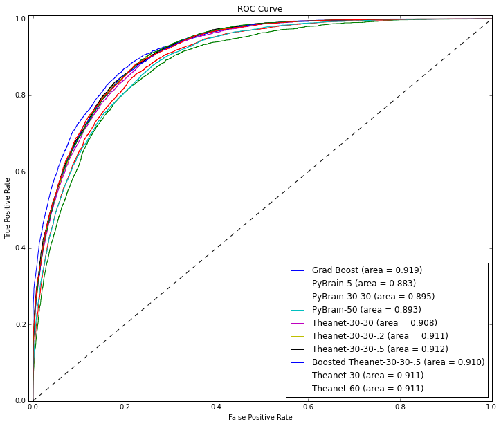

```python
Roc_Plot_Show()
```